# Ramen Ranking

affandry taufik

2023-02-06

## 0.1 R Markdown

```r
noodle <- read.csv("Datainput/ramen-lists.csv")
str(noodle)
```

```
## 'data.frame':    2580 obs. of  7 variables:
##  $ Review..: int  2580 2579 2578 2577 2576 2575 2574 2573 2572 2571 ...
##  $ Brand   : chr  "New Touch" "Just Way" "Nissin" "Wei Lih" ...
##  $ Variety : chr  "T's Restaurant Tantanmen " "Noodles Spicy Hot Sesame Spicy Hot Sesame Guan-miao Noodles" "Cup Noodles Chicken Vegetable" "GGE Ramen Snack Tomato Flavor" ...
##  $ Style   : chr  "Cup" "Pack" "Cup" "Pack" ...
##  $ Country : chr  "Japan" "Taiwan" "USA" "Taiwan" ...
##  $ Stars   : chr  "3.75" "1" "2.25" "2.75" ...
##  $ Top.Ten : chr  "" "" "" "" ...
```

```r
noodle$Review.. <- as.integer(noodle$Review..)
noodle$Brand <- as.factor(noodle$Brand)
noodle$Variety <- as.factor(noodle$Variety)
noodle$Country <- as.factor(noodle$Country)
noodle$Stars <- as.factor(noodle$Stars)
noodle$Top.Ten <- as.factor(noodle$Top.Ten)
noodle$Style <- as.factor(noodle$Style)

str(noodle)
```

```
## 'data.frame':    2580 obs. of  7 variables:
##  $ Review..: int  2580 2579 2578 2577 2576 2575 2574 2573 2572 2571 ...
##  $ Brand   : Factor w/ 355 levels "1 To 3 Noodles",..: 193 122 195 339 38 252 8 110 236 137 ...
##  $ Variety : Factor w/ 2413 levels "\"A\" Series Artificial Chicken",..: 2193 1446 457 721 1955 1110 2056 1373 814 2230 ...
##  $ Style   : Factor w/ 8 levels "","Bar","Bowl",..: 6 7 6 7 7 7 6 8 7 7 ...
##  $ Country : Factor w/ 38 levels "Australia","Bangladesh",..: 19 33 37 33 17 31 19 19 19 30 ...
##  $ Stars   : Factor w/ 51 levels "0","0.1","0.25",..: 37 7 16 19 37 47 39 37 3 18 ...
##  $ Top.Ten : Factor w/ 39 levels "","\n","2012 #1",..: 1 1 1 1 1 1 1 1 1 1 ...
```

```r
noodle$Stars <- as.numeric(as.character(noodle$Stars))
noodle <- noodle[-c(33,123,994),]
str(noodle)
```

```
## 'data.frame':    2577 obs. of  7 variables:
##  $ Review..: int  2580 2579 2578 2577 2576 2575 2574 2573 2572 2571 ...
##  $ Brand   : Factor w/ 355 levels "1 To 3 Noodles",..: 193 122 195 339 38 252 8 110 236 137 ...
##  $ Variety : Factor w/ 2413 levels "\"A\" Series Artificial Chicken",..: 2193 1446 457 721 1955 1110 2056 1373 814 2230 ...
##  $ Style   : Factor w/ 8 levels "","Bar","Bowl",..: 6 7 6 7 7 7 6 8 7 7 ...
##  $ Country : Factor w/ 38 levels "Australia","Bangladesh",..: 19 33 37 33 17 31 19 19 19 30 ...
##  $ Stars   : num  3.75 1 2.25 2.75 3.75 4.75 4 3.75 0.25 2.5 ...
##  $ Top.Ten : Factor w/ 39 levels "","\n","2012 #1",..: 1 1 1 1 1 1 1 1 1 1 ...
```

```r
levels(noodle$Country)
```

```
##  [1] "Australia"     "Bangladesh"    "Brazil"        "Cambodia"
##  [5] "Canada"        "China"         "Colombia"      "Dubai"
##  [9] "Estonia"       "Fiji"          "Finland"       "Germany"
## [13] "Ghana"         "Holland"       "Hong Kong"     "Hungary"
## [17] "India"         "Indonesia"     "Japan"         "Malaysia"
## [21] "Mexico"        "Myanmar"       "Nepal"         "Netherlands"
## [25] "Nigeria"       "Pakistan"      "Philippines"   "Poland"
## [29] "Sarawak"       "Singapore"     "South Korea"   "Sweden"
## [33] "Taiwan"        "Thailand"      "UK"            "United States"
## [37] "USA"           "Vietnam"
```

```r
noodle$Sub.Region[noodle$Country=="Australia"]<-"Australia"
noodle$Sub.Region[noodle$Country=="Bangladesh"]<-"South Asia"
noodle$Sub.Region[noodle$Country=="Brazil"]<-"South America"
noodle$Sub.Region[noodle$Country=="Cambodia"]<-"Southeast Asia"
noodle$Sub.Region[noodle$Country=="Canada"]<-"North America"
noodle$Sub.Region[noodle$Country=="China"]<-"East Asia"
noodle$Sub.Region[noodle$Country=="Colombia"]<-"South America"
noodle$Sub.Region[noodle$Country=="Dubai"]<-"Middle East"
noodle$Sub.Region[noodle$Country=="Estonia"]<-"North Europe"
noodle$Sub.Region[noodle$Country=="Fiji"]<-"Oceania"
noodle$Sub.Region[noodle$Country=="Finland"]<-"North Europe"
noodle$Sub.Region[noodle$Country=="Germany"]<-"West Europe"
noodle$Sub.Region[noodle$Country=="Ghana"]<-"West Africa"
noodle$Sub.Region[noodle$Country=="Holland"]<-"West Europe"
noodle$Sub.Region[noodle$Country=="Hong Kong"]<-"East Asia"
noodle$Sub.Region[noodle$Country=="Hungary"]<-"Central Europe"
noodle$Sub.Region[noodle$Country=="India"]<-"South Asia"
noodle$Sub.Region[noodle$Country=="Indonesia"]<-"Southeast Asia"
noodle$Sub.Region[noodle$Country=="Japan"]<-"East Asia"
noodle$Sub.Region[noodle$Country=="Malaysia"]<-"Southeast Asia"
noodle$Sub.Region[noodle$Country=="Mexico"]<-"North America"
noodle$Sub.Region[noodle$Country=="Myanmar"]<-"Southeast Asia"
noodle$Sub.Region[noodle$Country=="Nepal"]<-"South Asia"
noodle$Sub.Region[noodle$Country=="Netherlands"]<-"West Europe"
noodle$Sub.Region[noodle$Country=="Nigeria"]<-"West Africa"
noodle$Sub.Region[noodle$Country=="Pakistan"]<-"South Asia"
noodle$Sub.Region[noodle$Country=="Philippines"]<-"Southeast Asia"
noodle$Sub.Region[noodle$Country=="Poland"]<-"Central Europe"
noodle$Sub.Region[noodle$Country=="Sarawak"]<-"Southeast Asia"
noodle$Sub.Region[noodle$Country=="Singapore"]<-"Southeast Asia"
noodle$Sub.Region[noodle$Country=="South Korea"]<-"East Asia"
noodle$Sub.Region[noodle$Country=="Sweden"]<-"North Europe"
noodle$Sub.Region[noodle$Country=="Taiwan"]<-"East Asia"
noodle$Sub.Region[noodle$Country=="Thailand"]<-"Southeast Asia"
noodle$Sub.Region[noodle$Country=="UK"]<-"West Europe"
noodle$Sub.Region[noodle$Country=="United States"]<-"North America"
noodle$Sub.Region[noodle$Country=="USA"]<-"North America"
noodle$Sub.Region[noodle$Country=="Vietnam"]<-"Southeast Asia"

noodle$Sub.Region <- as.factor(noodle$Sub.Region)
levels(noodle$Sub.Region)
```

```
##  [1] "Australia"      "Central Europe" "East Asia"      "Middle East"
##  [5] "North America"  "North Europe"   "Oceania"        "South America"
##  [9] "South Asia"     "Southeast Asia" "West Africa"    "West Europe"
```

```r
noodle$Region[noodle$Sub.Region=="Australia"]<-"Australia/Oceania"
noodle$Region[noodle$Sub.Region=="Central Europe"]<-"Europe"
noodle$Region[noodle$Sub.Region=="East Asia"]<-"Asia"
noodle$Region[noodle$Sub.Region=="Middle East"]<-"Asia"
noodle$Region[noodle$Sub.Region=="North America"]<-"America"
noodle$Region[noodle$Sub.Region=="North Europe"]<-"Europe"
noodle$Region[noodle$Sub.Region=="Oceania"]<-"Australia/Oceania"
noodle$Region[noodle$Sub.Region=="South America"]<-"America"
noodle$Region[noodle$Sub.Region=="South Asia"]<-"Asia"
noodle$Region[noodle$Sub.Region=="Southeast Asia"]<-"Asia"
noodle$Region[noodle$Sub.Region=="West Africa"]<-"Africa"
noodle$Region[noodle$Sub.Region=="West Europe"]<-"Europe"

noodle$Region <- as.factor(noodle$Region)
levels(noodle$Region)
```

```
## [1] "Africa"            "America"           "Asia"
## [4] "Australia/Oceania" "Europe"
```

```r
str(noodle)
```

```
## 'data.frame':    2577 obs. of  9 variables:
##  $ Review..  : int  2580 2579 2578 2577 2576 2575 2574 2573 2572 2571 ...
##  $ Brand     : Factor w/ 355 levels "1 To 3 Noodles",..: 193 122 195 339 38 252 8 110 236 137 ...
##  $ Variety   : Factor w/ 2413 levels "\"A\" Series Artificial Chicken",..: 2193 1446 457 721 1955 1110 2056 1373 814 2230 ...
##  $ Style     : Factor w/ 8 levels "","Bar","Bowl",..: 6 7 6 7 7 7 6 8 7 7 ...
##  $ Country   : Factor w/ 38 levels "Australia","Bangladesh",..: 19 33 37 33 17 31 19 19 19 30 ...
##  $ Stars     : num  3.75 1 2.25 2.75 3.75 4.75 4 3.75 0.25 2.5 ...
##  $ Top.Ten   : Factor w/ 39 levels "","\n","2012 #1",..: 1 1 1 1 1 1 1 1 1 1 ...
##  $ Sub.Region: Factor w/ 12 levels "Australia","Central Europe",..: 3 3 5 3 9 3 3 3 3 10 ...
##  $ Region    : Factor w/ 5 levels "Africa","America",..: 3 3 2 3 3 3 3 3 3 3 ...
```

```r
nrow(noodle)
```

```
## [1] 2577
```

```r
summary(noodle)
```

```
##     Review..         Brand                    Variety         Style
##  Min.   :   1   Nissin  : 381   Beef              :   7   Pack   :1528
##  1st Qu.: 645   Nongshim:  98   Chicken           :   7   Bowl   : 481
##  Median :1289   Maruchan:  76   Artificial Chicken:   6   Cup    : 450
##  Mean   :1289   Mama    :  71   Vegetable         :   6   Tray   : 108
##  3rd Qu.:1934   Paldo   :  66   Yakisoba          :   6   Box    :   6
##  Max.   :2580   Myojo   :  63   Miso Ramen        :   5          :   2
##                 (Other) :1822   (Other)           :2540   (Other):   2
##         Country         Stars           Top.Ten              Sub.Region
##  Japan      : 352   Min.   :0.000           :2536   East Asia     :1189
##  USA        : 323   1st Qu.:3.250   \n      :   4   Southeast Asia: 758
##  South Korea: 307   Median :3.750   2012 #1 :   1   North America : 390
##  Taiwan     : 224   Mean   :3.655   2012 #10:   1   West Europe   : 115
##  Thailand   : 191   3rd Qu.:4.250   2012 #2 :   1   South Asia    :  61
##  China      : 169   Max.   :5.000   2012 #3 :   1   Australia     :  22
##  (Other)    :1011                   (Other) :  33   (Other)       :  42
##                Region
##  Africa           :   3
##  America          : 401
##  Asia             :2011
##  Australia/Oceania:  26
##  Europe           : 136
##
##
```

there are 2577 variant instant noodle which distributed in 38 different countries in 5 continents. Based on the summary, we can find that Japan has the most variant of instant noodles in the world and followed by USA and South Korea. Since instant noodles founded in Asia, it’s not astonishing to see that at least 2011 different kinds of instant noodles can be found in all around Asia.

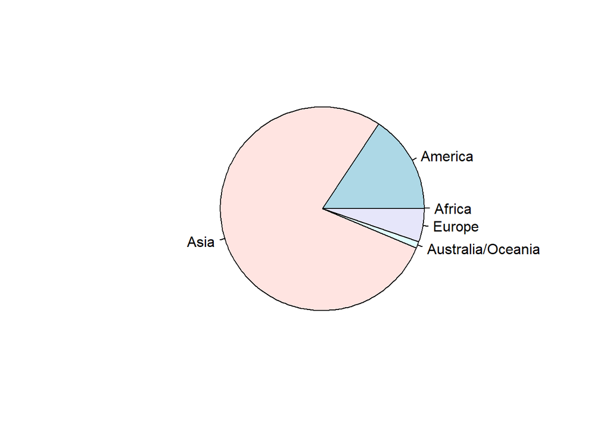

```r
graphics::pie(xtabs(~ Region, noodle))
```

Based on the pie chart above, we can see clearly that most variant of instant noodles can be found in Asia, with America and Europe following behind.

## 0.2 The Most Recognizable Brand

Based on the data summary, Nissin alone has 381 different products, which makes them the most recognizable instant noodles brand around the world. Nongshim from South Korea and Maruchan from United states can’t be leave aside as the second and the third brands which have more instant noodles variant.

```r
nissin <- as.data.frame(sort(prop.table(table(droplevels(noodle[noodle$Brand == "Nissin","Country"]))),decreasing = T))
names(nissin)[1] <- paste("Country")
nissin
```

| Country | Freq |
| --- | --- |
| Japan | 0.291338583 |
| USA | 0.249343832 |
| Hong Kong | 0.175853018 |
| Singapore | 0.070866142 |
| Germany | 0.057742782 |
| Mexico | 0.047244094 |
| Thailand | 0.044619423 |
| Colombia | 0.015748031 |
| India | 0.015748031 |
| Brazil | 0.013123360 |

[output cut: 4 more lines]

All Nissin’s 381 different products are distributed in 14 different countries, with around 70% of the products centered around Japan, USA and Hong Kong.

## 0.3 The Packaging of Instant Noodles

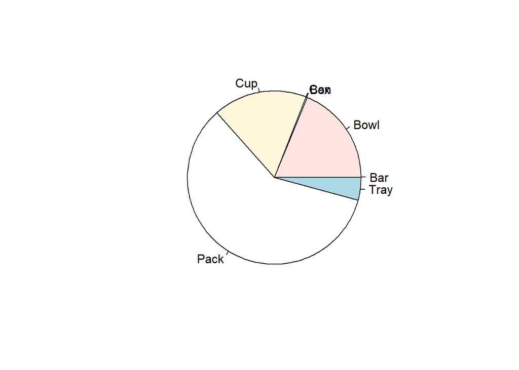

```r
graphics::pie(xtabs(~ Style, noodle))
```

```r
xtabs(~ Style + Region, noodle)
```

```
##       Region
## Style  Africa America Asia Australia/Oceania Europe
##             0       0    2                 0      0
##   Bar       0       1    0                 0      0
##   Bowl      0      78  401                 0      2
##   Box       0       1    5                 0      0
##   Can       0       1    0                 0      0
##   Cup       0     107  280                17     46
##   Pack      3     161 1267                 9     88
##   Tray      0      52   56                 0      0
```

We can find several type of packaging for instant noodles, but the most common one is the “pack” style, followed by bowl and cup.

## 0.4 What Do Customers Think About The Instant Noodles?

There can be a lot of instant noodle in the market, but how do we know whether it’s good or not? The easiest way to find out each instant noodle tastiness is by finding reviews and ratings from other customers.

```r
africa.mean <- (mean(noodle$Stars[noodle$Region == "Africa"]))
america.mean <- (mean(noodle$Stars[noodle$Region == "America"]))
asia.mean <- (mean(noodle$Stars[noodle$Region == "Asia"]))
australia.mean <- (mean(noodle$Stars[noodle$Region == "Australia/Oceania"]))
europe.mean <- (mean(noodle$Stars[noodle$Region == "Europe"]))

region.mean <- cbind(Region=c("Africa","America","Asia","Australia/Oceania","Europe"))
region.mean <- cbind(region.mean,as.data.frame(c(africa.mean,america.mean,asia.mean,australia.mean,europe.mean)))

names(region.mean)[2] <- paste("Mean")
region.mean
```

| Region | Mean |
| --- | --- |
| Africa | 2.833333 |
| America | 3.359414 |
| Asia | 3.752797 |
| Australia/Oceania | 3.251923 |
| Europe | 3.169485 |

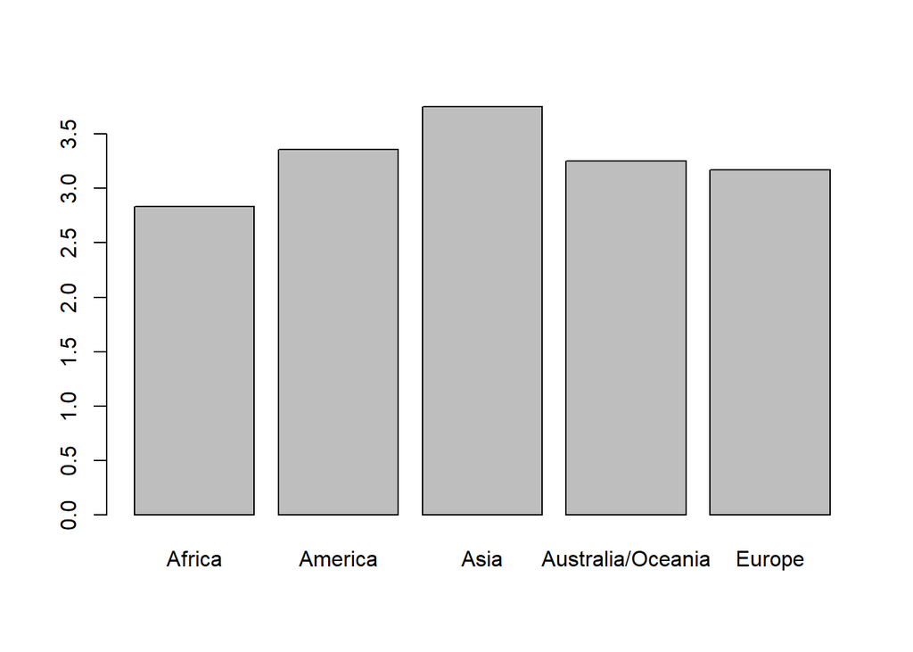

```r
graphics::barplot(xtabs(Mean ~ Region, region.mean))
```

Based on data, most of instant noodles in Asia can be categorized as delicious, because the average of the instant noodle rating in Asia is 3.75. We can say that you can go wrong when you pick any instant noodle in Asia. On the other hand, you need to do more research when you want to buy instant noodle in Africa, since the average rating for its’ instant noodles is 2.83.

```r
noodle$Stars.Range <-c("0-1", "1-2", "2-3", "3-4", "4-5")[findInterval(as.numeric(as.character(noodle$Stars)) , c(0, 1, 2, 3, 4, Inf) )]
xtabs(~ Stars.Range + Region, noodle)
```

```
##            Region
## Stars.Range Africa America Asia Australia/Oceania Europe
##         0-1      0      17   32                 0      5
##         1-2      1      24   67                 1     10
##         2-3      0      53  174                 6     17
##         3-4      2     168  780                10     83
##         4-5      0     139  958                 9     21
```

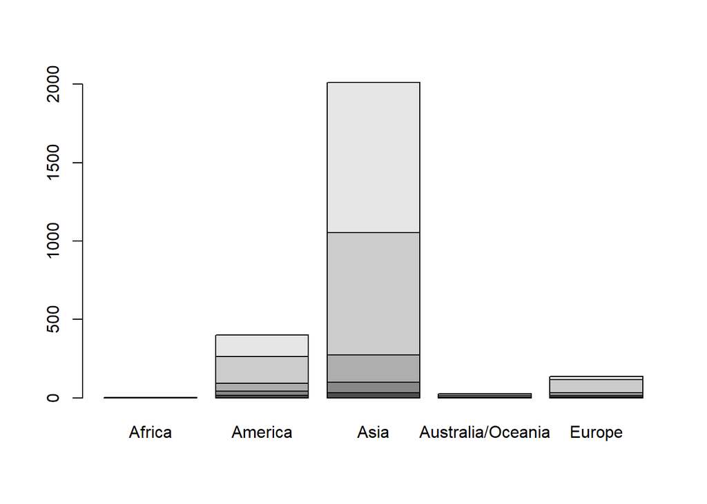

```r
graphics::barplot(xtabs(~ Stars.Range + Region, noodle))
```

```r
table(droplevels(noodle$Country),noodle$Stars.Range)
```

```
##
##                 0-1 1-2 2-3 3-4 4-5
##   Australia       0   1   6   9   6
##   Bangladesh      0   0   0   3   4
##   Brazil          0   0   0   0   5
##   Cambodia        0   0   0   2   3
##   Canada          7   7  12  12   3
##   China          10  10  12  71  66
##   Colombia        0   0   1   5   0
##   Dubai           0   0   0   3   0
##   Estonia         0   0   0   2   0
##   Fiji            0   0   0   1   3
##   Finland         0   0   0   3   0
##   Germany         0   0   0  22   5
##   Ghana           0   0   0   2   0
##   Holland         0   0   0   4   0
##   Hong Kong       1   3  14  41  78
##   Hungary         0   0   1   6   2
##   India           0   2   5  17   7
##   Indonesia       0   2   5  37  82
##   Japan           4   7  20 105 216
##   Malaysia        0   1   9  51  94
##   Mexico          0   0   0  11  14
##   Myanmar         0   0   2   7   5
##   Nepal           0   1   0  10   3
##   Netherlands     3   1   3   7   1
##   Nigeria         0   1   0   0   0
##   Pakistan        0   1   1   6   1
##   Philippines     2   3   6  22  14
##   Poland          0   0   0   2   2
##   Sarawak         0   0   0   0   3
##   Singapore       0   0   7  37  65
##   South Korea     3   6  25 128 145
##   Sweden          0   0   0   3   0
##   Taiwan          5  16  20  81 102
##   Thailand        5   9  27  96  54
##   UK              2   9  13  34  11
##   United States   0   0   0   1   0
##   USA            10  17  40 139 117
##   Vietnam         2   6  21  63  16
```

## 0.5 Asia - The Heaven of Instant Noodle

```r
asia <- subset(noodle, Region == "Asia")
str(asia)
```

```
## 'data.frame':    2011 obs. of  10 variables:
##  $ Review..   : int  2580 2579 2577 2576 2575 2574 2573 2572 2571 2570 ...
##  $ Brand      : Factor w/ 355 levels "1 To 3 Noodles",..: 193 122 339 38 252 8 110 236 137 291 ...
##  $ Variety    : Factor w/ 2413 levels "\"A\" Series Artificial Chicken",..: 2193 1446 721 1955 1110 2056 1373 814 2230 420 ...
##  $ Style      : Factor w/ 8 levels "","Bar","Bowl",..: 6 7 7 7 7 6 8 7 7 7 ...
##  $ Country    : Factor w/ 38 levels "Australia","Bangladesh",..: 19 33 33 17 31 19 19 19 30 34 ...
##  $ Stars      : num  3.75 1 2.75 3.75 4.75 4 3.75 0.25 2.5 5 ...
##  $ Top.Ten    : Factor w/ 39 levels "","\n","2012 #1",..: 1 1 1 1 1 1 1 1 1 1 ...
##  $ Sub.Region : Factor w/ 12 levels "Australia","Central Europe",..: 3 3 3 9 3 3 3 3 10 10 ...
##  $ Region     : Factor w/ 5 levels "Africa","America",..: 3 3 3 3 3 3 3 3 3 3 ...
##  $ Stars.Range: chr  "3-4" "1-2" "2-3" "3-4" ...
```

```r
summary(asia)
```

```
##     Review..           Brand                        Variety         Style
##  Min.   :   2.0   Nissin  : 234   Artificial Chicken    :   6   Pack   :1267
##  1st Qu.: 620.5   Mama    :  71   Beef                  :   5   Bowl   : 401
##  Median :1309.0   Paldo   :  66   Yakisoba              :   5   Cup    : 280
##  Mean   :1281.4   Nongshim:  62   Artificial Beef Flavor:   4   Tray   :  56
##  3rd Qu.:1914.5   Myojo   :  57   Artificial Spicy Beef :   4   Box    :   5
##  Max.   :2580.0   Indomie :  52   Chicken               :   4          :   2
##                   (Other) :1469   (Other)               :1983   (Other):   0
##         Country        Stars           Top.Ten              Sub.Region
##  Japan      :352   Min.   :0.000           :1971   East Asia     :1189
##  South Korea:307   1st Qu.:3.250   \n      :   4   Southeast Asia: 758
##  Taiwan     :224   Median :3.750   2012 #1 :   1   South Asia    :  61
##  Thailand   :191   Mean   :3.753   2012 #10:   1   Middle East   :   3
##  China      :169   3rd Qu.:4.500   2012 #2 :   1   Australia     :   0
##  Malaysia   :155   Max.   :5.000   2012 #3 :   1   Central Europe:   0
##  (Other)    :613                   (Other) :  32   (Other)       :   0
##                Region     Stars.Range
##  Africa           :   0   Length:2011
##  America          :   0   Class :character
##  Asia             :2011   Mode  :character
##  Australia/Oceania:   0
##  Europe           :   0
##
##
```

Asia as the origin of instant noodles can be said as the heaven of instant noodles. There are at least 2011 different varieties of instant noodles, which more half of those variants can be found in East Asia. Furthermore, we can also see that Southeast Asia also not fall behind from East Asia. It has at least 758 variants of instant noodles, which are higher that the sum of instant noodles variants in 4 other regions. For instant noodles in Asia, in terms of tastiness, with a strong 3.75 stars rating on average, you hardly can go wrong when you choose instant noodles in Asia.

```r
noodle.sub.asia <- as.data.frame(sort(table(droplevels(asia$Sub.Region)),decreasing = T))
names(noodle.sub.asia)[1]<-paste("Sub.Region")
noodle.sub.asia
```

| Sub.Region | Freq |
| --- | --- |
| East Asia | 1189 |
| Southeast Asia | 758 |
| South Asia | 61 |
| Middle East | 3 |

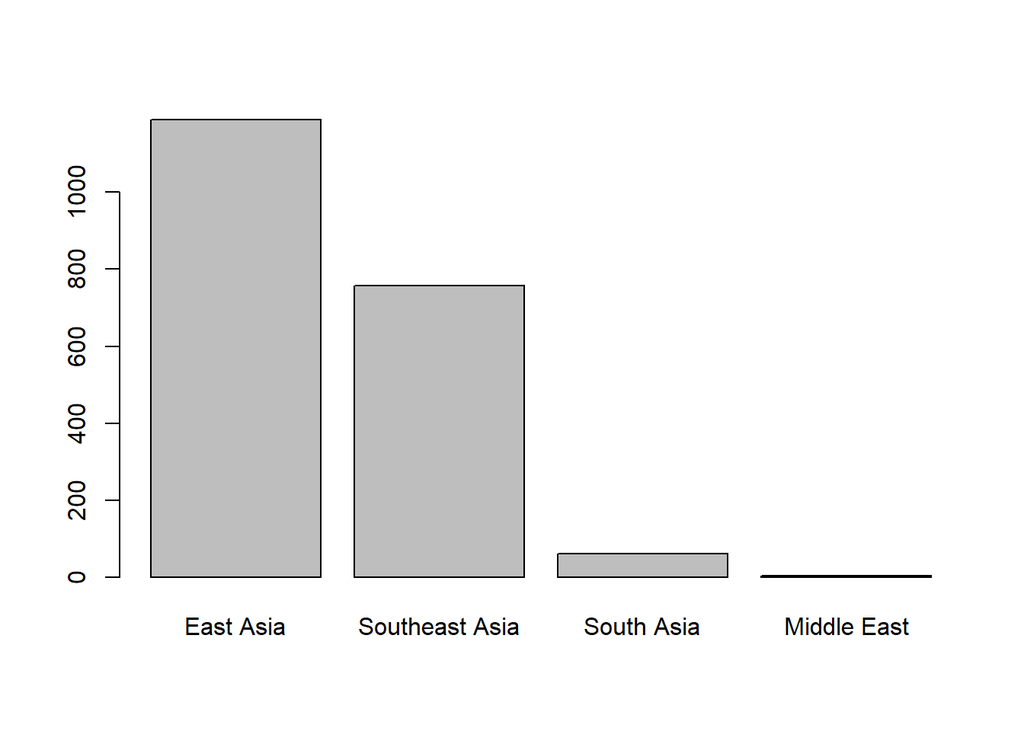

```r
graphics::barplot(xtabs(Freq ~ Sub.Region, noodle.sub.asia))
```

```r
noodle.asia <- as.data.frame(sort(table(droplevels(asia$Country)),decreasing = T))
names(noodle.asia)[1]<-paste("Country")
noodle.asia
```

| Country | Freq |
| --- | --- |
| Japan | 352 |
| South Korea | 307 |
| Taiwan | 224 |
| Thailand | 191 |
| China | 169 |
| Malaysia | 155 |
| Hong Kong | 137 |
| Indonesia | 126 |
| Singapore | 109 |
| Vietnam | 108 |

[output cut: 9 more lines]

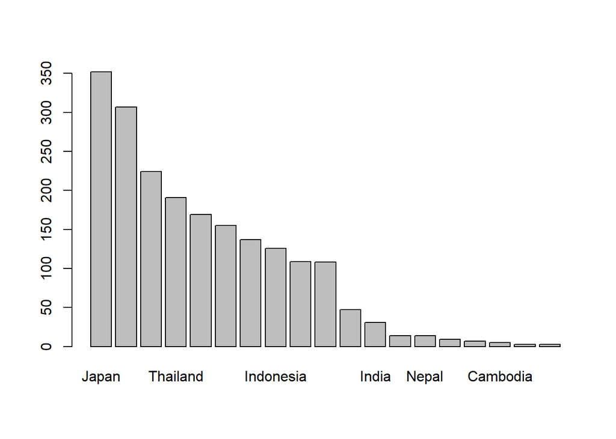

```r
graphics::barplot(xtabs(Freq ~ Country, noodle.asia))
```

## 0.6 What About Instant Noodle in Indonesia?

Instant noodle firstly introduced in Indonesia in 1968 with the brand Supermie. Nowadays, instant noodles become a comfort food, which is a significant part of the Indonesian diet.

```r
ina <- subset(noodle, Country == "Indonesia")
ina <- ina[,-c(5)]
names(ina)
```

```
## [1] "Review.."    "Brand"       "Variety"     "Style"       "Stars"
## [6] "Top.Ten"     "Sub.Region"  "Region"      "Stars.Range"
```

```r
str(ina)
```

```
## 'data.frame':    126 obs. of  9 variables:
##  $ Review..   : int  2549 2507 2463 2438 2417 2399 2374 2075 2052 1922 ...
##  $ Brand      : Factor w/ 355 levels "1 To 3 Noodles",..: 195 112 195 343 284 112 343 171 112 172 ...
##  $ Variety    : Factor w/ 2413 levels "\"A\" Series Artificial Chicken",..: 715 1798 716 1265 186 1370 1258 1299 1629 876 ...
##  $ Style      : Factor w/ 8 levels "","Bar","Bowl",..: 7 7 7 7 7 7 7 7 6 6 ...
##  $ Stars      : num  4.5 4 3.25 5 3.75 4 4.5 4.5 3.5 1.5 ...
##  $ Top.Ten    : Factor w/ 39 levels "","\n","2012 #1",..: 1 1 1 1 1 1 1 1 1 1 ...
##  $ Sub.Region : Factor w/ 12 levels "Australia","Central Europe",..: 10 10 10 10 10 10 10 10 10 10 ...
##  $ Region     : Factor w/ 5 levels "Africa","America",..: 3 3 3 3 3 3 3 3 3 3 ...
##  $ Stars.Range: chr  "4-5" "4-5" "3-4" "4-5" ...
```

```r
summary(ina)
```

```
##     Review..            Brand                             Variety
##  Min.   :  44.0   Indomie  :52   Mi Goreng Jumbo Beef         :  2
##  1st Qu.: 724.2   ABC      :12   100 Green Chilli Soto Flavour:  1
##  Median : 868.5   Mi Sedaap:12   Beef                         :  1
##  Mean   : 991.5   SuperMi  : 8   Bihun Kuah Rasa Baso Sapi    :  1
##  3rd Qu.:1260.8   GaGa     : 7   Chicken                      :  1
##  Max.   :2549.0   Sarimi   : 7   Chicken Curry                :  1
##                   (Other)  :28   (Other)                      :119
##      Style         Stars          Top.Ten             Sub.Region
##  Pack   :104   Min.   :1.500          :120   Southeast Asia:126
##  Cup    : 21   1st Qu.:3.750   \n     :  2   Australia     :  0
##  Box    :  1   Median :4.000   2012 #1:  1   Central Europe:  0
##         :  0   Mean   :4.067   2012 #2:  1   East Asia     :  0
##  Bar    :  0   3rd Qu.:4.500   2012 #5:  1   Middle East   :  0
##  Bowl   :  0   Max.   :5.000   2013 #3:  1   North America :  0
##  (Other):  0                   (Other):  0   (Other)       :  0
##                Region    Stars.Range
##  Africa           :  0   Length:126
##  America          :  0   Class :character
##  Asia             :126   Mode  :character
##  Australia/Oceania:  0
##  Europe           :  0
##
##
```

```r
nrow(ina)
```

```
## [1] 126
```

```r
noodle.ina <- as.data.frame(sort(table(ina$Stars.Range), decreasing = T))
noodle.ina
```

| Var1 | Freq |
| --- | --- |
| 4-5 | 82 |
| 3-4 | 37 |
| 2-3 | 5 |
| 1-2 | 2 |

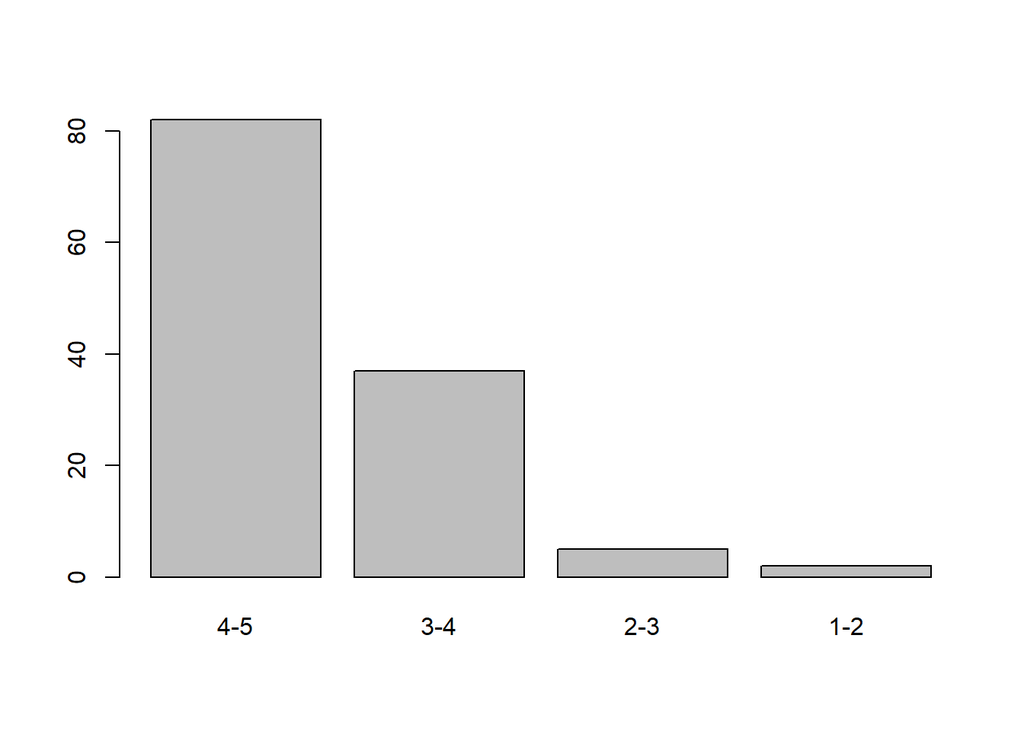

```r
graphics::barplot(xtabs(Freq ~ Var1,noodle.ina))
```

```r
noodle.ina2 <- as.data.frame(sort(table(droplevels(ina$Brand)), decreasing = T))
noodle.ina2
```

| Var1 | Freq |
| --- | --- |
| Indomie | 52 |
| ABC | 12 |
| Mi Sedaap | 12 |
| SuperMi | 8 |
| GaGa | 7 |
| Sarimi | 7 |
| Eat & Go | 5 |
| Super Bihun | 4 |
| Pop Bihun | 3 |
| Healtimie | 2 |

[output cut: 9 more lines]

```r
table(droplevels(ina$Brand),ina$Stars.Range)
```

```
##
##                   1-2 2-3 3-4 4-5
##   ABC               0   0   3   9
##   Cap Atoom Bulan   0   0   1   0
##   Eat & Go          0   0   2   3
##   GaGa              0   0   4   3
##   Healtimie         0   0   1   1
##   Indomie           1   5  10  36
##   La Fonte          0   0   1   1
##   Maitri            0   0   0   1
##   Mi Sedaap         0   0   3   9
##   Mie Sedaap        1   0   0   0
##   Nissin            0   0   1   1
##   Pop Bihun         0   0   2   1
##   President         0   0   0   1
##   Salam Mie         0   0   0   2
##   Sarimi            0   0   4   3
##   Super Bihun       0   0   2   2
##   SuperMi           0   0   1   7
##   Tropicana Slim    0   0   2   0
##   World O' Noodle   0   0   0   2
```

```r
prop.table(table(droplevels(ina$Brand),ina$Stars.Range== "4-5"))
```

```
##
##                         FALSE        TRUE
##   ABC             0.023809524 0.071428571
##   Cap Atoom Bulan 0.007936508 0.000000000
##   Eat & Go        0.015873016 0.023809524
##   GaGa            0.031746032 0.023809524
##   Healtimie       0.007936508 0.007936508
##   Indomie         0.126984127 0.285714286
##   La Fonte        0.007936508 0.007936508
##   Maitri          0.000000000 0.007936508
##   Mi Sedaap       0.023809524 0.071428571
##   Mie Sedaap      0.007936508 0.000000000
##   Nissin          0.007936508 0.007936508
##   Pop Bihun       0.015873016 0.007936508
##   President       0.000000000 0.007936508
##   Salam Mie       0.000000000 0.015873016
##   Sarimi          0.031746032 0.023809524
##   Super Bihun     0.015873016 0.015873016
##   SuperMi         0.007936508 0.055555556
##   Tropicana Slim  0.015873016 0.000000000
##   World O' Noodle 0.000000000 0.015873016
```

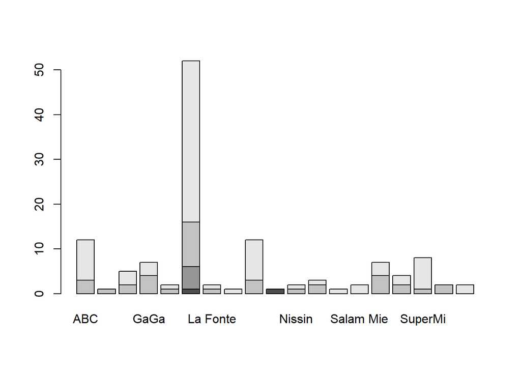

```r
graphics::barplot(table(ina$Stars.Range,droplevels(ina$Brand)))
```

## 0.7 Conclusion

Now, what do I know about instant noodle? I know that it was founded by Momofuku Ando of Nissin Foods under the brand name Chikin Ramen in Japan on 25 August 1958 Sixty One years since its’ inception, Japan still the biggest producer of instant noodles, which has at least 352 variant of instant noodles. Nissin is the biggest noodle producers which has 381 different products that distributed in 14 countries. Asia is the heaven of instant noodles, because you can find 2011 out of 2577 instant noodles variant all across Asia. Most of instant noodles in Asia are the delicious one, because, on average, Asia’s instant noodles got 3.75 star for it’s taste. However, don’t forget about Indonesia, with average of 4.06 star rating, Indonesia became one of the Asian countries which has a higher star rating than the average of Asia’s star rating.